# Moses Olusola Okesola Recell Project

**Problem Statement**

**Business Context**

Buying and selling used phones and tablets used to be something that happened on a handful of online marketplace sites. But the used and refurbished device market has grown considerably over the past decade, and a new IDC (International Data Corporation) forecast predicts that the used phone market would be worth $ 52.7bn by 2023 with a compound annual growth rate (CAGR) of 13.6% from 2018 to 2023. This growth can be attributed to an uptick in demand for used phones and tablets that offer considerable savings compared with new models.

Refurbished and used devices continue to provide cost-effective alternatives to both consumers and businesses that are looking to save money when purchasing one. There are plenty of other benefits associated with the used device market. Used and refurbished devices can be sold with warranties and can also be insured with proof of purchase. Third-party vendors/platforms, such as Verizon, Amazon, etc., provide attractive offers to customers for refurbished devices. Maximizing the longevity of devices through second-hand trade also reduces their environmental impact and helps in recycling and reducing waste. The impact of the COVID-19 outbreak may further boost this segment as consumers cut back on discretionary spending and buy phones and tablets only for immediate needs.

Objective The rising potential of this comparatively under-the-radar market fuels the need for an ML-based solution to develop a dynamic pricing strategy for used and refurbished devices. ReCell, a startup aiming to tap the potential in this market, has hired you as a data scientist. They want you to analyze the data provided and build a linear regression model to predict the price of a used phone/tablet and identify factors that significantly influence it.

Data Description The data contains the different attributes of used/refurbished phones and tablets. The data was collected in the year 2021. The detailed data dictionary is given below.

brand_name: Name of manufacturing brand os: OS on which the device runs screen_size: Size of the screen in cm 4g: Whether 4G is available or not 5g: Whether 5G is available or not main_camera_mp: Resolution of the rear camera in megapixels selfie_camera_mp: Resolution of the front camera in megapixels int_memory: Amount of internal memory (ROM) in GB ram: Amount of RAM in GB battery: Energy capacity of the device battery in mAh weight: Weight of the device in grams release_year: Year when the device model was released days_used: Number of days the used/refurbished device has been used normalized_new_price: Normalized price of a new device of the same model in euros normalized_used_price: Normalized price of the used/refurbished device in euros

**Import Necessary Libraries**

```python
# this will help in making the Python code more structured automatically (good coding practice)
%load_ext nb_black

# Libraries to help with reading and manipulating data
import numpy as np
import pandas as pd

# Libraries to help with data visualization
import matplotlib.pyplot as plt
import seaborn as sns

sns.set()

# split the data into train and test
from sklearn.model_selection import train_test_split

# to build linear regression_model
from sklearn.linear_model import LinearRegression

# to check model performance
from sklearn.metrics import mean_absolute_error, mean_squared_error, r2_score

# to build linear regression_model using statsmodels
import statsmodels.api as sm

# to compute VIF
from statsmodels.stats.outliers_influence import variance_inflation_factor
```

**Load the Dataset**

```python
Rcel = pd.read_csv("/Users/Moses Okesola/Downloads/used_device_data.csv")
Rcel.head()
```

|  | brand_name | os | screen_size | 4g | 5g | main_camera_mp | selfie_camera_mp | int_memory | ram | battery | weight | release_year | days_used | normalized_used_price | normalized_new_price |
| --- | --- | --- | --- | --- | --- | --- | --- | --- | --- | --- | --- | --- | --- | --- | --- |
| 0 | Honor | Android | 14.50 | yes | no | 13.0 | 5.0 | 64.0 | 3.0 | 3020.0 | 146.0 | 2020 | 127 | 4.307572 | 4.715100 |
| 1 | Honor | Android | 17.30 | yes | yes | 13.0 | 16.0 | 128.0 | 8.0 | 4300.0 | 213.0 | 2020 | 325 | 5.162097 | 5.519018 |
| 2 | Honor | Android | 16.69 | yes | yes | 13.0 | 8.0 | 128.0 | 8.0 | 4200.0 | 213.0 | 2020 | 162 | 5.111084 | 5.884631 |
| 3 | Honor | Android | 25.50 | yes | yes | 13.0 | 8.0 | 64.0 | 6.0 | 7250.0 | 480.0 | 2020 | 345 | 5.135387 | 5.630961 |
| 4 | Honor | Android | 15.32 | yes | no | 13.0 | 8.0 | 64.0 | 3.0 | 5000.0 | 185.0 | 2020 | 293 | 4.389995 | 4.947837 |

```python
Rcel.T
```

|  | 0 | 1 | 2 | 3 | 4 | 5 | 6 | 7 | 8 | 9 | ... | 3444 | 3445 | 3446 | 3447 | 3448 | 3449 | 3450 | 3451 | 3452 | 3453 |
| --- | --- | --- | --- | --- | --- | --- | --- | --- | --- | --- | --- | --- | --- | --- | --- | --- | --- | --- | --- | --- | --- |
| brand_name | Honor | Honor | Honor | Honor | Honor | Honor | Honor | Honor | Honor | Honor | ... | Apple | Apple | Apple | Apple | Asus | Asus | Asus | Alcatel | Alcatel | Alcatel |
| os | Android | Android | Android | Android | Android | Android | Android | Android | Android | Android | ... | iOS | iOS | iOS | iOS | Android | Android | Android | Android | Android | Android |
| screen_size | 14.5 | 17.3 | 16.69 | 25.5 | 15.32 | 16.23 | 13.84 | 15.77 | 15.32 | 16.23 | ... | 10.34 | 15.37 | 12.9 | 15.27 | 16.74 | 15.34 | 15.24 | 15.8 | 15.8 | 12.83 |
| 4g | yes | yes | yes | yes | yes | yes | yes | yes | yes | yes | ... | yes | yes | yes | yes | yes | yes | yes | yes | yes | yes |
| 5g | no | yes | yes | yes | no | no | no | no | no | no | ... | no | no | no | no | no | no | no | no | no | no |
| main_camera_mp | 13.0 | 13.0 | 13.0 | 13.0 | 13.0 | 13.0 | 8.0 | 13.0 | 13.0 | 13.0 | ... | 12.0 | 8.0 | 8.0 | 8.0 | NaN | NaN | 13.0 | 13.0 | 13.0 | 13.0 |
| selfie_camera_mp | 5.0 | 16.0 | 8.0 | 8.0 | 8.0 | 8.0 | 5.0 | 8.0 | 16.0 | 8.0 | ... | 7.0 | 7.0 | 7.0 | 7.0 | 24.0 | 8.0 | 8.0 | 5.0 | 5.0 | 5.0 |
| int_memory | 64.0 | 128.0 | 128.0 | 64.0 | 64.0 | 64.0 | 32.0 | 64.0 | 128.0 | 128.0 | ... | 64.0 | 64.0 | 64.0 | 64.0 | 128.0 | 64.0 | 128.0 | 32.0 | 32.0 | 16.0 |
| ram | 3.0 | 8.0 | 8.0 | 6.0 | 3.0 | 4.0 | 2.0 | 4.0 | 6.0 | 6.0 | ... | 3.0 | 4.0 | 4.0 | 4.0 | 8.0 | 6.0 | 8.0 | 3.0 | 2.0 | 2.0 |
| battery | 3020.0 | 4300.0 | 4200.0 | 7250.0 | 5000.0 | 4000.0 | 3020.0 | 3400.0 | 4000.0 | 4000.0 | ... | 1821.0 | 3969.0 | 3046.0 | 3110.0 | 6000.0 | 5000.0 | 4000.0 | 4000.0 | 4000.0 | 4000.0 |
| weight | 146.0 | 213.0 | 213.0 | 480.0 | 185.0 | 176.0 | 144.0 | 164.0 | 165.0 | 176.0 | ... | 148.0 | 226.0 | 188.0 | 194.0 | 240.0 | 190.0 | 200.0 | 165.0 | 160.0 | 168.0 |
| release_year | 2020 | 2020 | 2020 | 2020 | 2020 | 2020 | 2020 | 2020 | 2020 | 2020 | ... | 2020 | 2019 | 2019 | 2019 | 2019 | 2019 | 2018 | 2020 | 2020 | 2020 |
| days_used | 127 | 325 | 162 | 345 | 293 | 223 | 234 | 219 | 161 | 327 | ... | 235 | 298 | 351 | 208 | 325 | 232 | 541 | 201 | 149 | 176 |
| normalized_used_price | 4.307572 | 5.162097 | 5.111084 | 5.135387 | 4.389995 | 4.413889 | 3.878259 | 4.729421 | 4.886054 | 4.773224 | ... | 5.011901 | 5.340466 | 5.440164 | 5.100902 | 5.715316 | 4.492337 | 5.037732 | 4.35735 | 4.349762 | 4.132122 |
| normalized_new_price | 4.7151 | 5.519018 | 5.884631 | 5.630961 | 4.947837 | 5.060694 | 4.518958 | 5.188726 | 5.299916 | 5.07361 | ... | 5.875352 | 6.734175 | 6.713746 | 6.287933 | 7.059317 | 6.483872 | 6.251538 | 4.528829 | 4.624188 | 4.279994 |

15 rows × 3454 columns

Check the shape of the dataset

```python
Rcel.shape
```

```
(3454, 15)
```

There are 3454 rows and 15 columns.

Get the information regarding column datatypes

```python
Rcel.info()
```

```
<class 'pandas.core.frame.DataFrame'>
RangeIndex: 3454 entries, 0 to 3453
Data columns (total 15 columns):
 #   Column                 Non-Null Count  Dtype
---  ------                 --------------  -----
 0   brand_name             3454 non-null   object
 1   os                     3454 non-null   object
 2   screen_size            3454 non-null   float64
 3   4g                     3454 non-null   object
 4   5g                     3454 non-null   object
 5   main_camera_mp         3275 non-null   float64
 6   selfie_camera_mp       3452 non-null   float64
 7   int_memory             3450 non-null   float64
 8   ram                    3450 non-null   float64
 9   battery                3448 non-null   float64
 10  weight                 3447 non-null   float64
 11  release_year           3454 non-null   int64
 12  days_used              3454 non-null   int64
 13  normalized_used_price  3454 non-null   float64
 14  normalized_new_price   3454 non-null   float64
dtypes: float64(9), int64(2), object(4)
memory usage: 404.9+ KB
```

There are eleven numeric( nine float and two integer type) and four string( object type) columns in the dataset.

**List all the columns in the dataset**

```python
Rcel.columns
```

```
Index(['brand_name', 'os', 'screen_size', '4g', '5g', 'main_camera_mp',
       'selfie_camera_mp', 'int_memory', 'ram', 'battery', 'weight',
       'release_year', 'days_used', 'normalized_used_price',
       'normalized_new_price'],
      dtype='object')
```

**Get summary statistics for the dataset**

```python
Rcel.describe(include="all").T
```

|  | count | unique | top | freq | mean | std | min | 25% | 50% | 75% | max |
| --- | --- | --- | --- | --- | --- | --- | --- | --- | --- | --- | --- |
| brand_name | 3454 | 34 | Others | 502 | NaN | NaN | NaN | NaN | NaN | NaN | NaN |
| os | 3454 | 4 | Android | 3214 | NaN | NaN | NaN | NaN | NaN | NaN | NaN |
| screen_size | 3454.0 | NaN | NaN | NaN | 13.713115 | 3.80528 | 5.08 | 12.7 | 12.83 | 15.34 | 30.71 |
| 4g | 3454 | 2 | yes | 2335 | NaN | NaN | NaN | NaN | NaN | NaN | NaN |
| 5g | 3454 | 2 | no | 3302 | NaN | NaN | NaN | NaN | NaN | NaN | NaN |
| main_camera_mp | 3275.0 | NaN | NaN | NaN | 9.460208 | 4.815461 | 0.08 | 5.0 | 8.0 | 13.0 | 48.0 |
| selfie_camera_mp | 3452.0 | NaN | NaN | NaN | 6.554229 | 6.970372 | 0.0 | 2.0 | 5.0 | 8.0 | 32.0 |
| int_memory | 3450.0 | NaN | NaN | NaN | 54.573099 | 84.972371 | 0.01 | 16.0 | 32.0 | 64.0 | 1024.0 |
| ram | 3450.0 | NaN | NaN | NaN | 4.036122 | 1.365105 | 0.02 | 4.0 | 4.0 | 4.0 | 12.0 |
| battery | 3448.0 | NaN | NaN | NaN | 3133.402697 | 1299.682844 | 500.0 | 2100.0 | 3000.0 | 4000.0 | 9720.0 |
| weight | 3447.0 | NaN | NaN | NaN | 182.751871 | 88.413228 | 69.0 | 142.0 | 160.0 | 185.0 | 855.0 |
| release_year | 3454.0 | NaN | NaN | NaN | 2015.965258 | 2.298455 | 2013.0 | 2014.0 | 2015.5 | 2018.0 | 2020.0 |
| days_used | 3454.0 | NaN | NaN | NaN | 674.869716 | 248.580166 | 91.0 | 533.5 | 690.5 | 868.75 | 1094.0 |
| normalized_used_price | 3454.0 | NaN | NaN | NaN | 4.364712 | 0.588914 | 1.536867 | 4.033931 | 4.405133 | 4.7557 | 6.619433 |
| normalized_new_price | 3454.0 | NaN | NaN | NaN | 5.233107 | 0.683637 | 2.901422 | 4.790342 | 5.245892 | 5.673718 | 7.847841 |

-The average normalized used devices price is approximately 4.4 Euros.

-The normalized used prices range from 1.54 to 6.6 Euros approximately.

-The normalized used median price is 4.4 Euros approximately which is comparable to its average value.

-The average normalized used price is 16.6% lesser than the normalized new price.

-The range of both the normalized used price and the normalized new price is the same, It is approximately 5 Euros.

**Check for duplicate values in the dataset**

```python
Rcel.duplicated().sum()
```

```
0
```

There are no duplicate values in the data

**Check for missing values in the dataset**

```python
Rcel.isnull().sum()
```

```
brand_name                 0
os                         0
screen_size                0
4g                         0
5g                         0
main_camera_mp           179
selfie_camera_mp           2
int_memory                 4
ram                        4
battery                    6
weight                     7
release_year               0
days_used                  0
normalized_used_price      0
normalized_new_price       0
dtype: int64
```

There are missing values in the following columns: main_camera_mp, selfie_camera_mp, int_memory, ram, battery,and weight.

**Create a copy of the data so that the original data remain unchanged**

```python
df = Rcel.copy()
```

**Exploratory Data Analysis (EDA) Summary**

```python
# Get the list of all numerical variables, including 'normalized_used_price'
numerical_vars_all = Rcel.select_dtypes(include=['float64', 'int64']).columns.tolist()

# Print the list of all numerical variables
print("All Numerical Variables:")
for var in numerical_vars_all:
    print(var)
```

```
All Numerical Variables:
screen_size
main_camera_mp
selfie_camera_mp
int_memory
ram
battery
weight
release_year
days_used
normalized_used_price
normalized_new_price
```

```python
# Extract features excluding the dependent variable 'normalized_used_price'
feature = Rcel.drop(columns=["normalized_used_price"])

# Check the extracted features
(feature.head()).T
```

|  | 0 | 1 | 2 | 3 | 4 |
| --- | --- | --- | --- | --- | --- |
| brand_name | Honor | Honor | Honor | Honor | Honor |
| os | Android | Android | Android | Android | Android |
| screen_size | 14.5 | 17.3 | 16.69 | 25.5 | 15.32 |
| 4g | yes | yes | yes | yes | yes |
| 5g | no | yes | yes | yes | no |
| main_camera_mp | 13.0 | 13.0 | 13.0 | 13.0 | 13.0 |
| selfie_camera_mp | 5.0 | 16.0 | 8.0 | 8.0 | 8.0 |
| int_memory | 64.0 | 128.0 | 128.0 | 64.0 | 64.0 |
| ram | 3.0 | 8.0 | 8.0 | 6.0 | 3.0 |
| battery | 3020.0 | 4300.0 | 4200.0 | 7250.0 | 5000.0 |
| weight | 146.0 | 213.0 | 213.0 | 480.0 | 185.0 |
| release_year | 2020 | 2020 | 2020 | 2020 | 2020 |
| days_used | 127 | 325 | 162 | 345 | 293 |
| normalized_new_price | 4.7151 | 5.519018 | 5.884631 | 5.630961 | 4.947837 |

The features are the independent variables of the dataset.

**Data visualization of numerical variables by histogram_boxplot**

```python
# Histogram-boxplot combined plots for numerical variables
def histogram_boxplot(Rcel, feature, figsize=(15, 10), kde=False, bins=None):
    """
    Boxplot and histogram combined

    Rcel: dataframe
    feature: dataframe column
    figsize: size of figure (default (15,10))
    kde: whether to show the density curve (default False)
    bins: number of bins for histogram (default None)
    """
    f2, (ax_box2, ax_hist2) = plt.subplots(
        nrows=2,
        sharex=True,
        gridspec_kw={"height_ratios": (0.25, 0.75)},
        figsize=figsize,
    )
    sns.boxplot(data=Rcel, x=feature, ax=ax_box2, showmeans=True, color="violet")

    if bins:
        sns.histplot(data=Rcel, x=feature, kde=kde, ax=ax_hist2, bins=bins)
    else:
        sns.histplot(data=Rcel, x=feature, kde=kde, ax=ax_hist2)

    ax_hist2.axvline(Rcel[feature].mean(), color="green", linestyle="--")  # Add mean to the histogram
    ax_hist2.axvline(Rcel[feature].median(), color="black", linestyle="-")  # Add median to the histogram
```

**Data visualization of categorical variables by labelled barplot**

```python
# function to create labeled barplots


def labeled_barplot(data, feature, perc=False, n=None):
    """
    Barplot with percentage at the top

    data: dataframe
    feature: dataframe column
    perc: whether to display percentages instead of count (default is False)
    n: displays the top n category levels (default is None, i.e., display all levels)
    """

    total = len(data[feature])  # length of the column
    count = data[feature].nunique()
    if n is None:
        plt.figure(figsize=(count + 2, 6))
    else:
        plt.figure(figsize=(n + 2, 6))

    plt.xticks(rotation=90, fontsize=15)
    ax = sns.countplot(
        data=data,
        x=feature,
        palette="Paired",
        order=data[feature].value_counts().index[:n],
    )

    for p in ax.patches:
        if perc == True:
            label = "{:.1f}%".format(
                100 * p.get_height() / total
            )  # percentage of each class of the category
        else:
            label = p.get_height()  # count of each level of the category

        x = p.get_x() + p.get_width() / 2  # width of the plot
        y = p.get_height()  # height of the plot

        ax.annotate(
            label,
            (x, y),
            ha="center",
            va="center",
            size=12,
            xytext=(0, 5),
            textcoords="offset points",
        )  # annotate the percentage

    plt.show()  # show the plot
```

**normalized used price**

**Question:What does the distribution of normalized used device prices look like?**

```python
# the column that contains information about the normalized used prices
normalized_used_price_class = df["normalized_used_price"].unique()
normalized_used_price_class
```

```
array([4.30757245, 5.16209665, 5.11108377, ..., 5.03773152, 4.35734965,
       4.34976167])
```

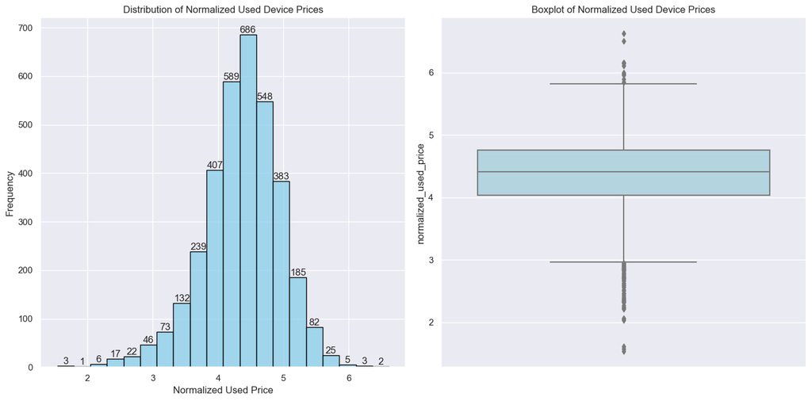

```python
# plotting the distribution of normalized used device prices

plt.figure(figsize=(14, 7))

# Subplot 1: Histogram of normalized used device prices with count labels
plt.subplot(1, 2, 1)
ax1 = sns.histplot(df["normalized_used_price"], bins=20, color="skyblue", edgecolor="black")
plt.title("Distribution of Normalized Used Device Prices")
plt.xlabel("Normalized Used Price")
plt.ylabel("Frequency")

# Add count labels to the histogram
for rect in ax1.patches:
    height = rect.get_height()
    ax1.text(rect.get_x() + rect.get_width() / 2, height, height, ha='center', va='bottom')

# Subplot 2: Boxplot of normalized used device prices
plt.subplot(1, 2, 2)
ax2 = sns.boxplot(y="normalized_used_price", data=df, color="lightblue")
plt.title("Boxplot of Normalized Used Device Prices")

plt.tight_layout()
plt.show()
```

-The normalized used price distribution is normal. -The least The normalized used devices price is slightly above 1.5 Euros.

-The lowest frequency of a normalized used devices price is 1 and at close to 2 Euros.

-The highest normalized used devices price is close to 7 Euros.

-The highest frequency of a normalized used devices price is 686 and at between 4.3 to 4.6 Euros.

-Extreme normalized used prices occured at slightly below 3 Euros and above 5.8 Euros.

**OS-Operating Systems**

```python
# the column that contains information about the operating systems
os_types = df["os"].unique()
os_types
```

```
array(['Android', 'Others', 'iOS', 'Windows'], dtype=object)
```

```python
# Plot the labeled barplot for the OS on which the device runs
labeled_barplot(df, "os", perc=True, n=10)
```

[output not shown]

-OS Android-type is 93.1% of the market of used devices.

-OS Others-type is 4% of the market of used devices.

-OS Window-type is 1.9% of the market of used devices.

-OS IOS-type is 1% of the market of used devices.

**Question: What percentage of the used device market is dominated by Android devices?**

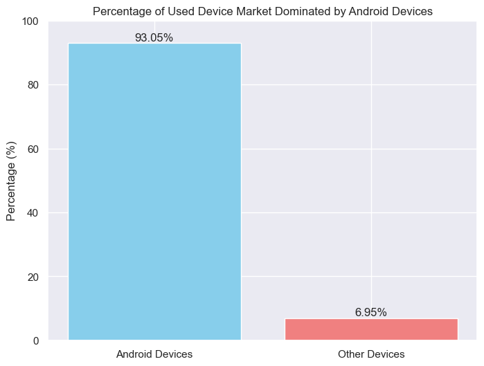

```python
# Calculate the percentage of the used device market dominated by Android devices
total_devices = len(df)
android_devices = len(df[df["os"] == "Android"])
android_market_share = (android_devices / total_devices) * 100

# Create a vertical bar plot to visualize the market share
plt.figure(figsize=(8, 6))
plt.bar(
    ["Android Devices", "Other Devices"],
    [android_market_share, 100 - android_market_share],
    color=["skyblue", "lightcoral"],
)
plt.ylabel("Percentage (%)")
plt.title("Percentage of Used Device Market Dominated by Android Devices")
plt.ylim(0, 100)  # Set y-axis limits from 0 to 100 for percentage scale

# Display the percentage values on the bars
for index, value in enumerate([android_market_share, 100 - android_market_share]):
    plt.text(index, value, f"{value:.2f}%", ha="center", va="bottom")

plt.show()
```

The percentage of the used devices market dominated by Android devices is 93.05%, and that of other operating system categories is 6.95%.

**RAM**

```python
# the column that contains information about the RAM
ram_sizes = df["ram"].unique()
ram_sizes
```

```
array([ 3.  ,  8.  ,  6.  ,  4.  ,  2.  ,  1.  , 12.  ,  0.5 ,  0.25,
        0.03,   nan,  0.02,  1.5 ])
```

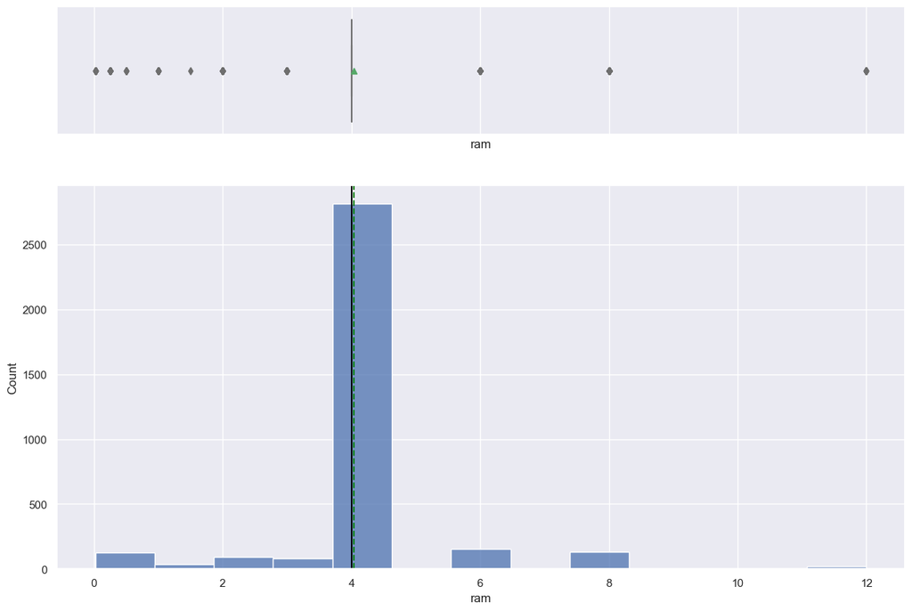

```python
# Plot the histogram and boxplot for amount of RAM
histogram_boxplot(df, "ram")
```

-The distribution of RAM is right-skewed with a few scattered extreme values on both sides of the plot.

**Sreen size**

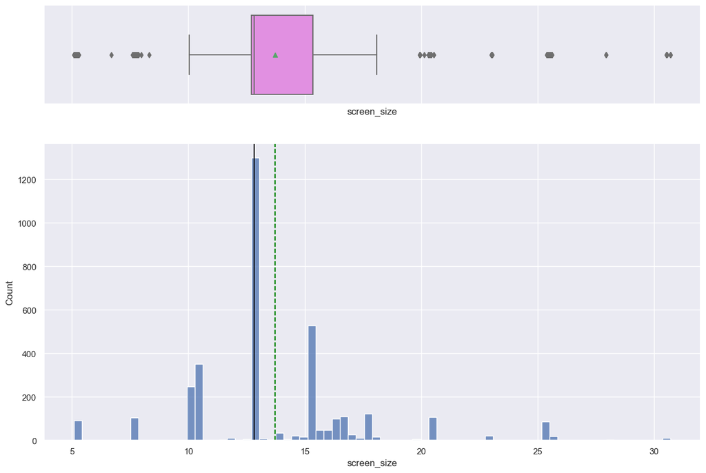

```python
# Plot the histogram and boxplot for the screen size
histogram_boxplot(df, "screen_size")
```

The distribution of screen_size is right-skewed with some outliers on both sides of the plot.

**Normalized new price**

```python
# the column that contains information about the normalized new prices
normalized_new_price_class = df["normalized_new_price"].unique()
normalized_new_price_class
```

```
array([4.71510025, 5.51901794, 5.88463072, ..., 6.25153773, 4.62418819,
       4.27999391])
```

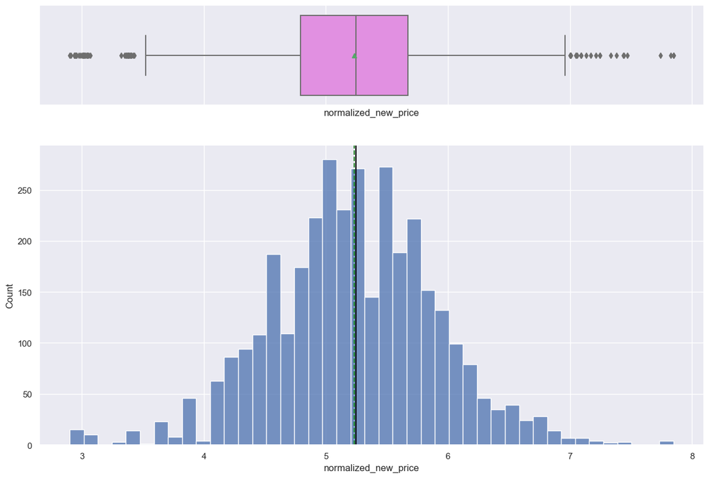

```python
# plot the histogram-boxplot for Normalized price of a new device of the same model
histogram_boxplot(df, "normalized_new_price")
```

normalized_new_price distribution is normal with outliers on both sides of the plot.

**Main camera mp: the resolution of the rear camera**

```python
# the column that contains information about the resolution of the rear camera
main_camera_mp_types = df["main_camera_mp"].unique()
main_camera_mp_types
```

```
array([13.  ,  8.  ,  5.  , 10.5 ,  3.15,   nan,  2.  , 16.  ,  0.3 ,
       12.  , 14.5 , 48.  ,  3.  , 21.  ,  1.3 , 13.1 , 24.  ,  0.08,
       20.7 , 23.  ,  1.  , 18.  , 12.2 , 12.3 , 20.  , 20.2 ,  4.  ,
       12.5 , 10.  ,  6.5 ,  6.7 , 41.  , 20.1 , 12.6 , 16.3 , 22.6 ,
       19.  , 21.5 , 21.2 ,  8.1 ,  1.2 , 22.5 ])
```

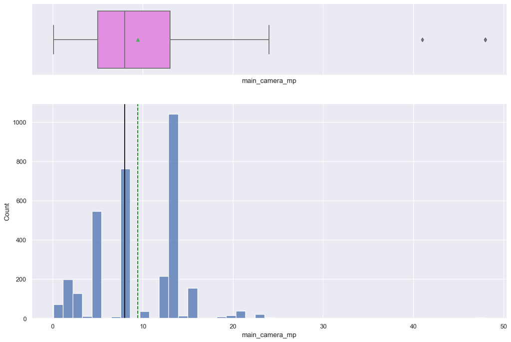

```python
# Plot the histogram and boxplot for the resolution of the rear camera
histogram_boxplot(df, "main_camera_mp")
```

**Selfie camera mp: the resolution of the front camera**

```python
# the column that contains information about the resolution of the frontcamera
selfie_camera_mp_types = df["selfie_camera_mp"].unique()
selfie_camera_mp_types
```

```
array([ 5.  , 16.  ,  8.  , 32.  ,  2.  ,  0.3 , 13.  , 14.5 , 24.  ,
       10.  ,  1.3 , 20.  , 25.  ,  0.  , 12.  ,  7.  ,  1.2 ,  3.  ,
        2.1 ,  1.  ,  4.  ,  1.1 ,   nan, 10.5 ,  1.6 ,  1.8 ,  3.5 ,
        0.9 ,  1.25, 18.  ,  1.9 ,  9.  ,  3.7 , 16.3 ,  5.1 ,  2.2 ,
       14.  ,  0.65])
```

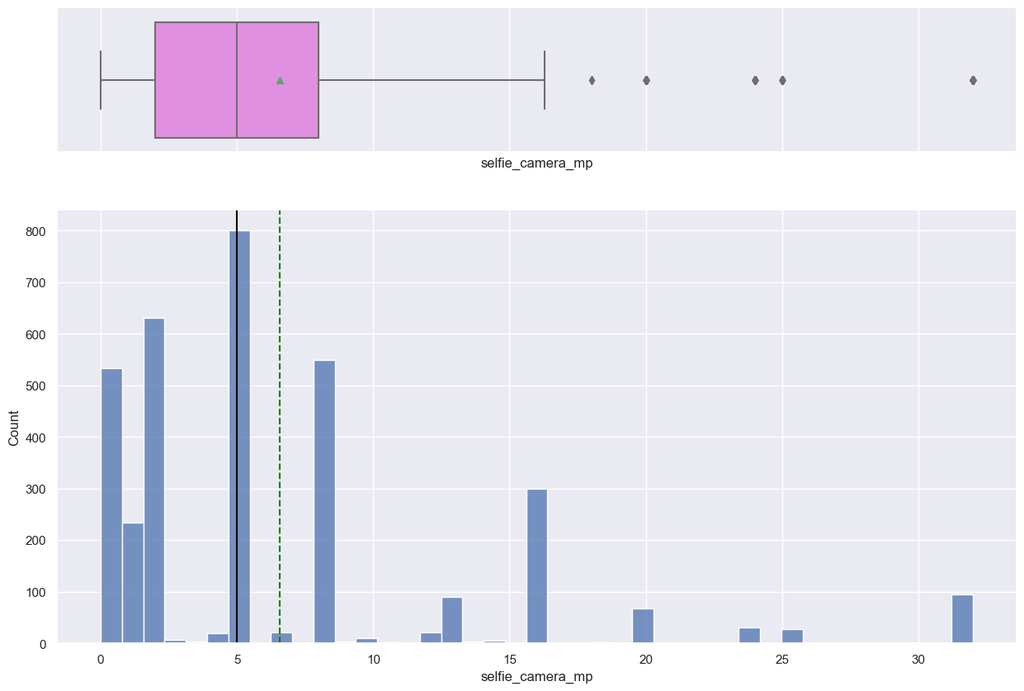

```python
# Plot the histogram and boxplot for the resolution of the front camera
histogram_boxplot(df, "selfie_camera_mp")
```

-selfie_camera_mp distribution is right-skewed with 0 minimum value and a maximum value above 31 megapixels. -There are a few extreme values to right of the distribution.

**Internal Memory**

```python
# the column that contains information about the internal memory
int_memory_sizes = df["int_memory"].unique()
int_memory_sizes
```

```
array([6.400e+01, 1.280e+02, 3.200e+01, 1.600e+01, 2.560e+02, 5.120e+02,
       8.000e+00, 4.000e+00, 5.000e-01, 2.000e-01, 1.000e-01, 6.000e-02,
             nan, 1.024e+03, 2.400e+01, 1.000e-02])
```

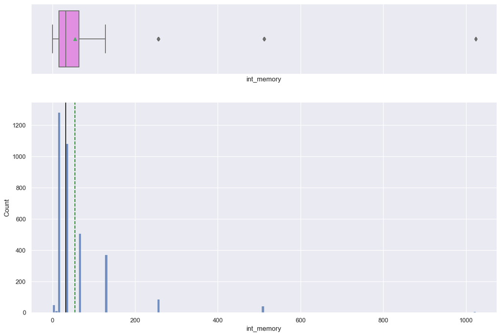

```python
# Plot the histogram and boxplot for the internal memory of the device
histogram_boxplot(df, "int_memory")
```

Internal memory distribution is right skewed with a few staggered extreme values. The least int_memory value is approximately zero.

**Weight of the device in grams**

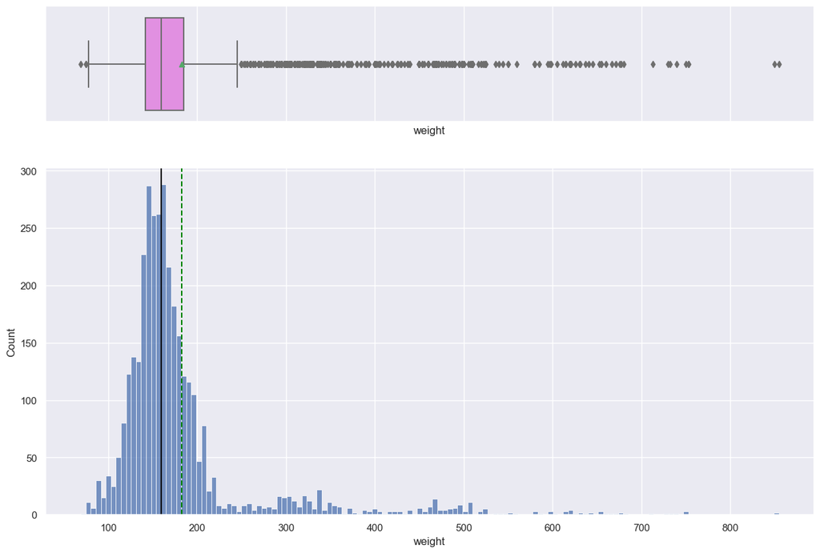

```python
# Plot the histogram and boxplot for the weight of the device
histogram_boxplot(df, "weight")
```

The weight of the device is right-skewed with a very high extreme values at the right side of the plot, though there a few extreme values at the left.

**battery: Energy capacity of the device battery in mAh**

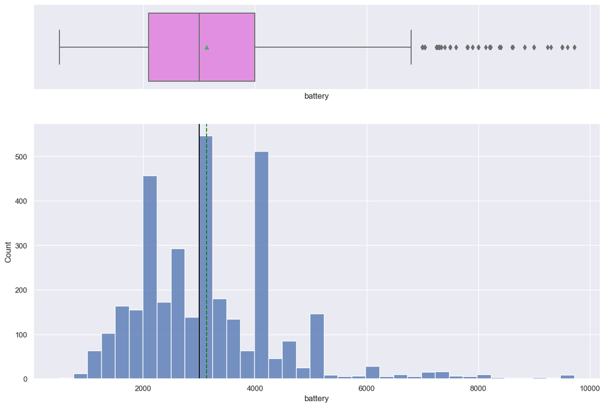

```python
# Plot the histogram and boxplot for the Energy capacity of the device battery
histogram_boxplot(df, "battery")
```

The distribution of the Energy capacity of the device battery is right-skewed with a lot of outliers at the right side of the plot.

**Days used : Number of days the used/refurbished device has been used**

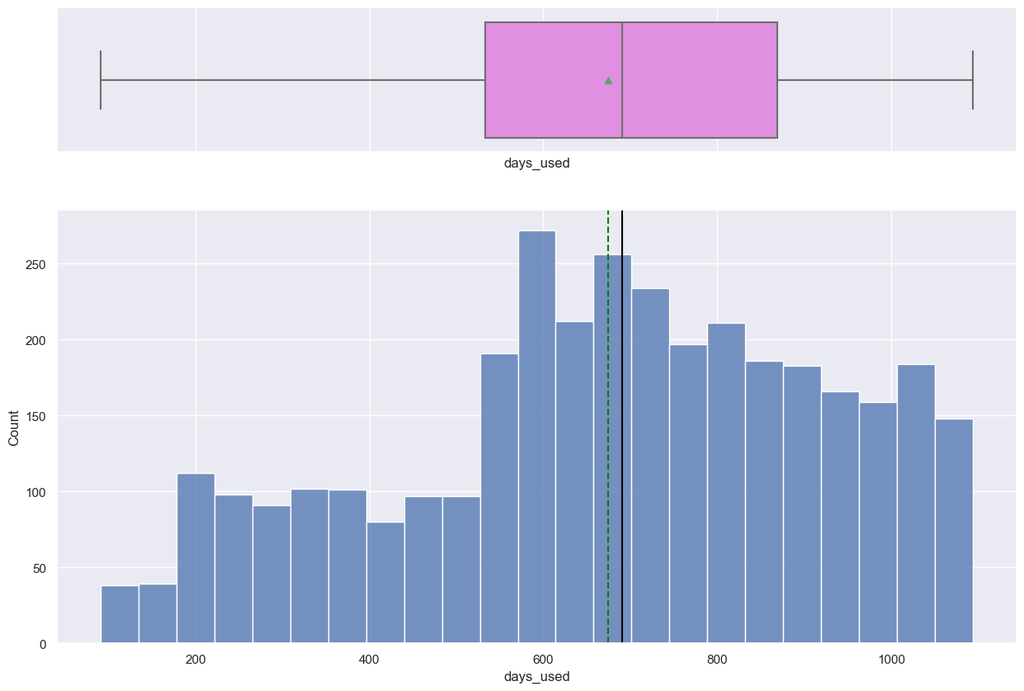

```python
# Plot the histogram and boxplot for the number of days the used/refurbished device has been used
histogram_boxplot(df, "days_used")
```

**brand_name**

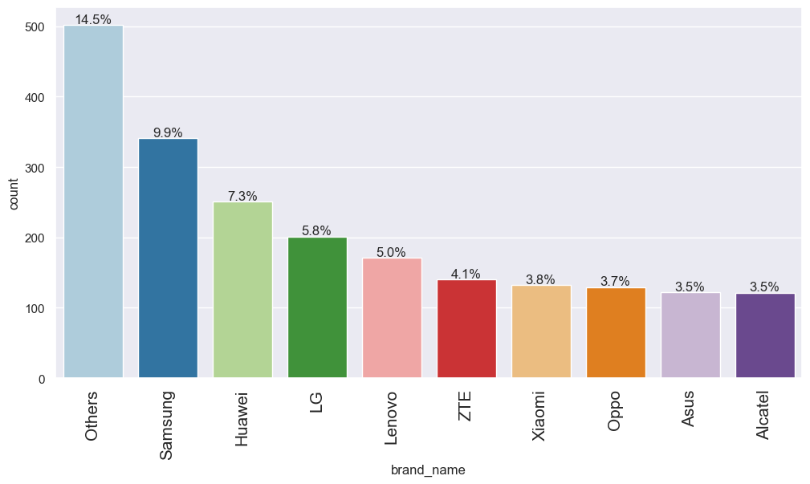

```python
# Plot the labeled barplot for the name of manufacturing brand
labeled_barplot(df, "brand_name", perc=True, n=10)
```

-The brand name distribution shows the percentage of market share of each manufacturing brand.

**4g**

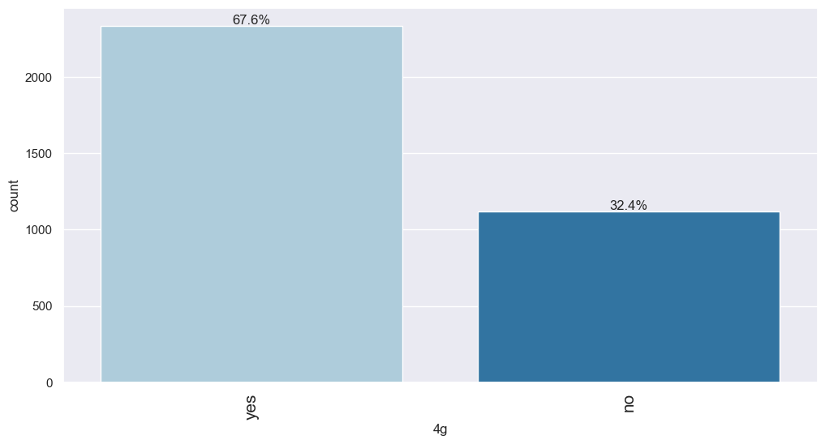

```python
# Plot the labeled barplot for the name of manufacturing brand
labeled_barplot(df, "4g", perc=True, n=10)
```

-There is 32.4% non-availability of the 4g devices in the market.

**5g**

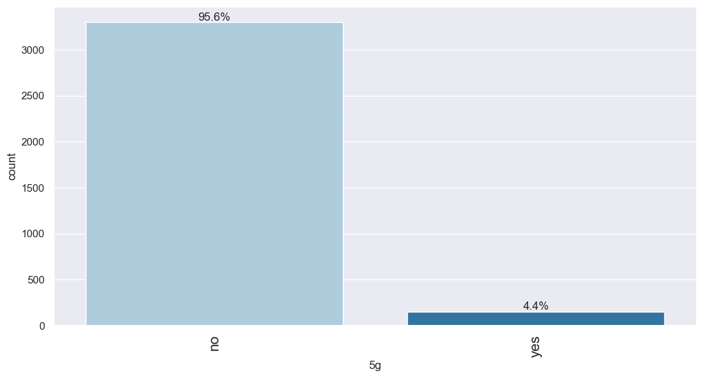

```python
# Plot the labeled barplot for the name of manufacturing brand
labeled_barplot(df, "5g", perc=True, n=10)
```

-There is 4.4% availability of the 5g devices in the market.

-There is 95.6% non-availability of the 5g devices in the market.

**os**

```python
# Plot the labeled barplot for the operating system of the devices
labeled_barplot(df, "os", perc=True, n=10)
```

[output not shown]

-Android operating system devices account for 93.1% of the market,which is the highest.

-The least in the market is the iOS operating system devices.

**release_year: Year when the device model was released**

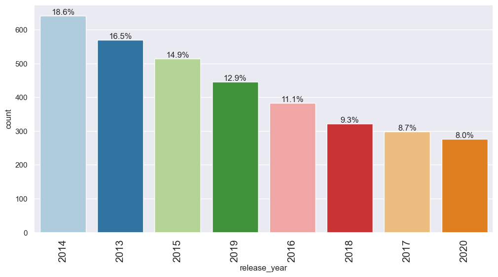

```python
# Plot the labeled barplot for the year when the device model was released
labeled_barplot(df, "release_year", perc=True, n=10)
```

-The plot indicates that a higher percentage (18.6%) of phone and tablet devices were released in 2014 compared to other years in the range.

**Bivariate Analysis**

**Correlation check**

**Question: Which attributes are highly correlated with the normalized price of a used device?**

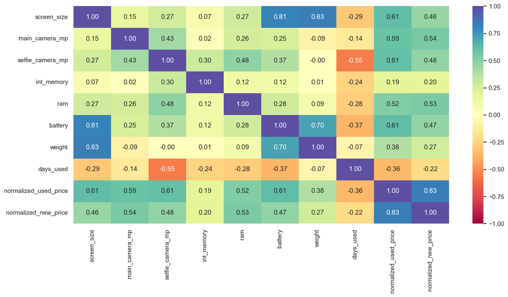

```python
cols_list = df.select_dtypes(include=np.number).columns.tolist()
# dropping release_year as it is a temporal variable
cols_list.remove("release_year")

plt.figure(figsize=(15, 7))
sns.heatmap(
    df[cols_list].corr(), annot=True, vmin=-1, vmax=1, fmt=".2f", cmap="Spectral"
)
plt.show()
```

-normalized_used_price has moderate positive corellation with screen_size, main_camera_mp, selfie_camera_mp, ram,battery,and strong positive correlation with normalized_new_price.

-The correlation between normalized_used_price and int_memory, and weight is weakly positive.

-normalized_used_price has weak negative correlation with days_used.

**Plot the scatterplots for numerical features and the target variable, normalized_used_price**

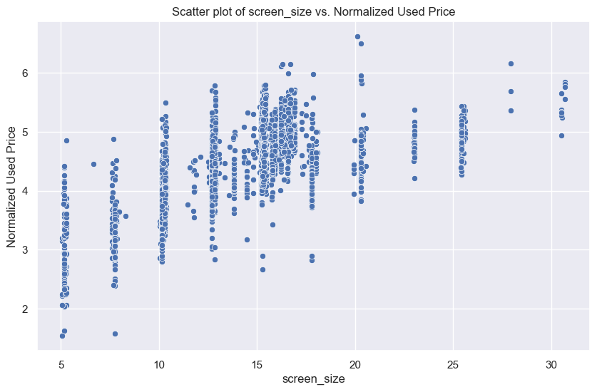

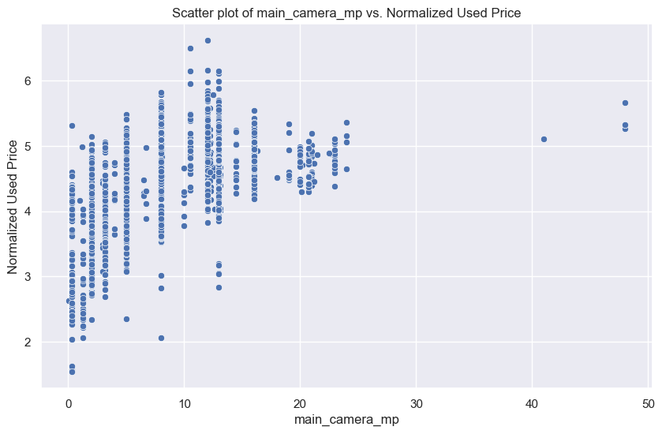

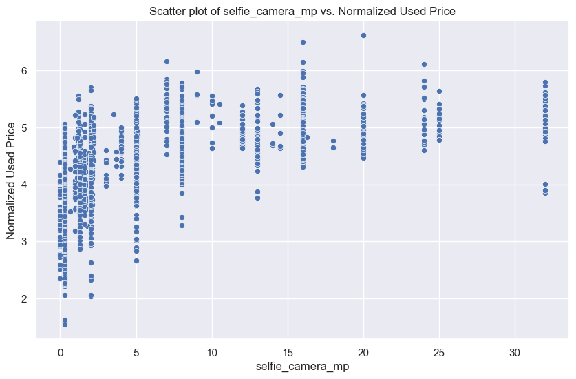

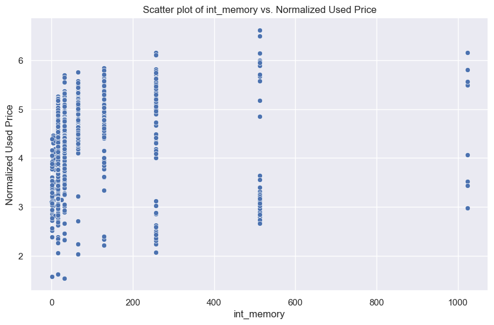

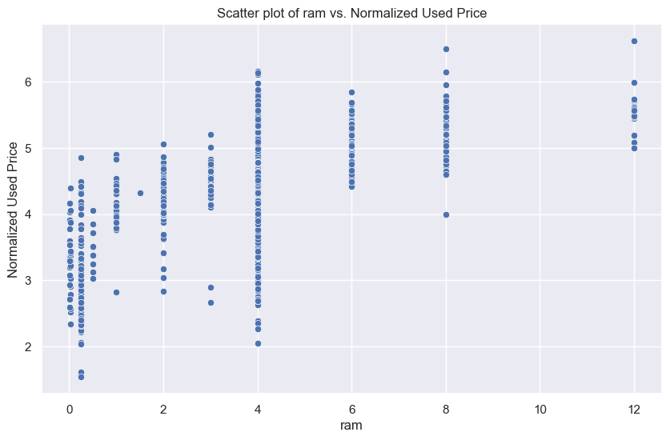

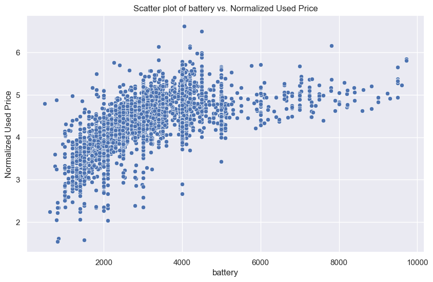

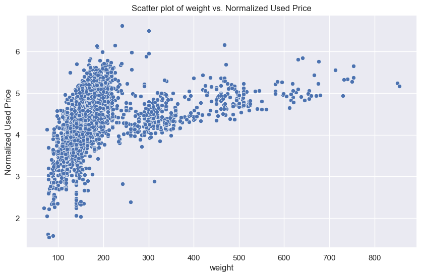

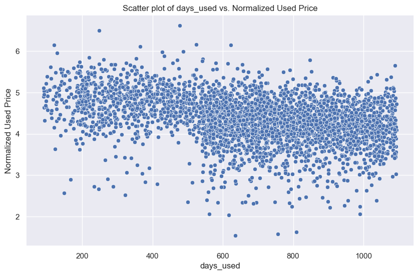

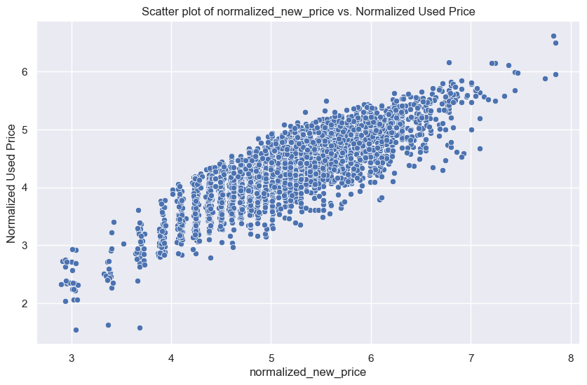

```python
# Get the list of all numerical variables, excluding 'normalized_used_price' and 'release_year'
numerical_vars_all = df.select_dtypes(include=["float64", "int64"]).columns.tolist()
numerical_vars = [var for var in numerical_vars_all if var not in ["normalized_used_price", "release_year"]]

# Creating scatter plots for each numerical feature against the normalized used price
for feature in numerical_vars:
    plt.figure(figsize=(10, 6))
    sns.scatterplot(data=df, x=feature, y="normalized_used_price")
    plt.title(f"Scatter plot of {feature} vs. Normalized Used Price")
    plt.xlabel(feature)
    plt.ylabel("Normalized Used Price")
    plt.show()
```

**Plot of normalized used price vs categorical variables**

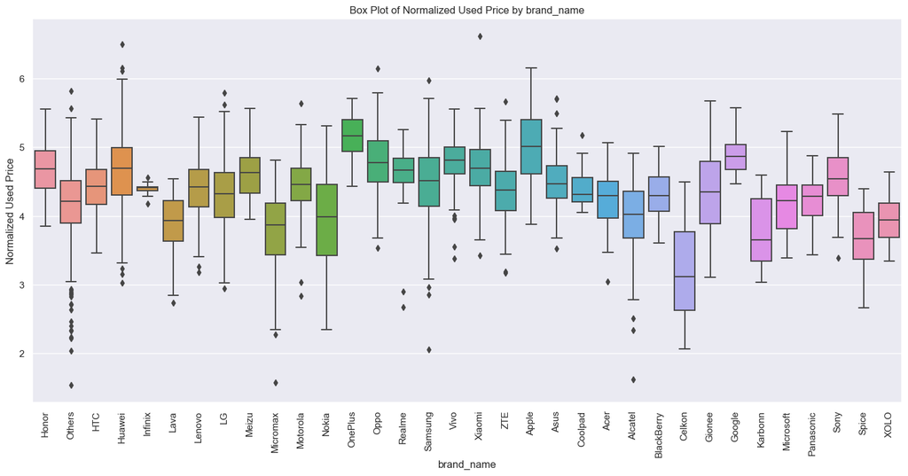

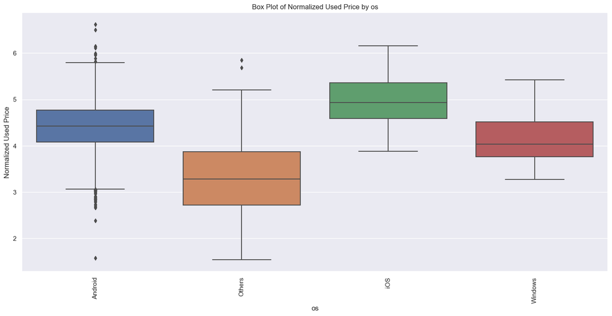

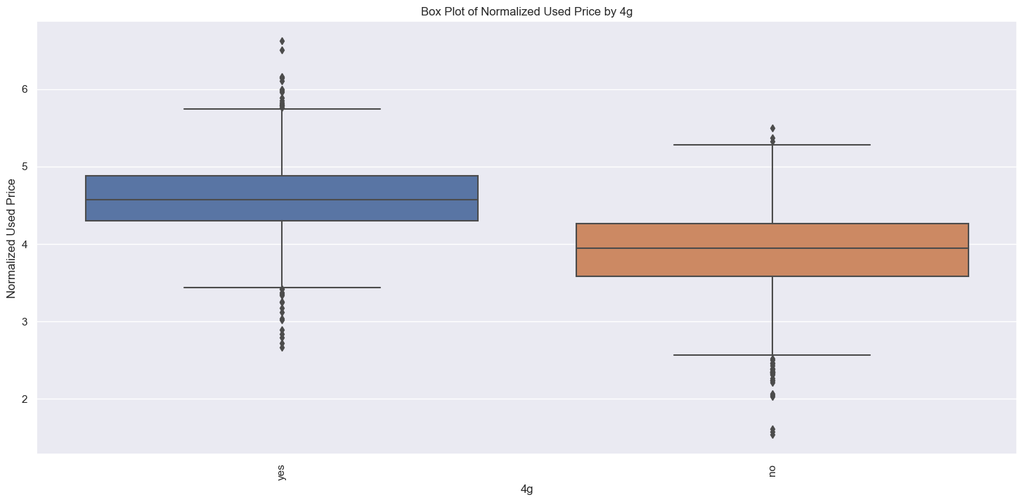

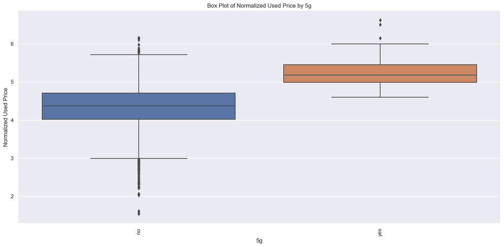

```python
# Create a box plot of the normalized used price versus categorical variables
cat_vars = df.select_dtypes(include=["object", "category"]).columns.tolist()
for feature in cat_vars:
    plt.figure(figsize=(18, 8))  # Set the figure size for each plot
    sns.boxplot(x=feature, y="normalized_used_price", data=df, width=0.8)
    plt.title(f"Box Plot of Normalized Used Price by {feature}")
    plt.xlabel(feature)
    plt.ylabel("Normalized Used Price")
    plt.xticks(rotation=90)
    plt.show()  # Display the plot in each iteration of the loop
```

-IOS-OS type has the highest normalized used price and Others-OS type has the lowest.

-Devices with 4g attracts higher normalized used price than used devices with no 4g.

-Devices with 5g attracts higher normalized used price than used devices with no 5g.

**Brand name vs RAM**

**Question: The amount of RAM is important for the smooth functioning of a device. How does the amount of RAM vary with the brand?**

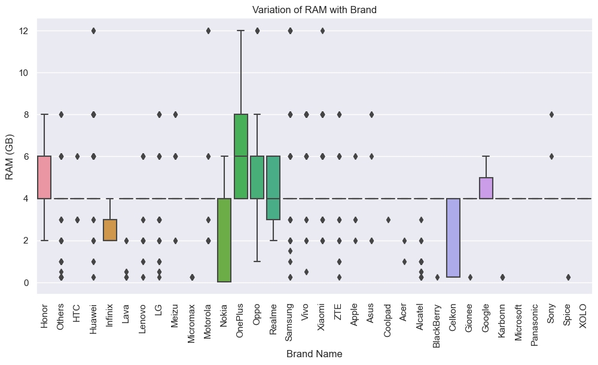

```python
# Variation of RAM with the brand

plt.figure(figsize=(12, 6))
sns.boxplot(x="brand_name", y="ram", data=df)
plt.title("Variation of RAM with Brand")
plt.xlabel("Brand Name")
plt.ylabel("RAM (GB)")
plt.xticks(rotation=90)
plt.show()
```

-OnePlus brand has the highest RAM, and Nokia has the lowest RAM. -There are more extreme values of RAM associated with many brands.